# Epidemiology

Roman Susdorf

October 21, 2018

## Epidemiology example I

The dataset used in the present analysis is available via the [LSHTM Data Repository](https://datacompass.lshtm.ac.uk/599/)

```r
scabies<-read.table("https://datacompass.lshtm.ac.uk/607/2/S1-Dataset_CSV.csv", header=T, sep=",")
```

In this example I will analyse the infestation with scabies using data from a cross-sectional survey conducted in the Solomon Islands in 2014. I want to acknowledge Michael Mark’s provision of data and tutorials which were very helpful.

```r
summary(scabies)
```

```
##        ID           Village            age           gender
##  Min.   :60001   Min.   : 1.000   Min.   : 0.00   female:1103
##  1st Qu.:60520   1st Qu.: 4.000   1st Qu.: 6.00   male  : 805
##  Median :61084   Median : 7.000   Median :12.00
##  Mean   :61109   Mean   : 6.379   Mean   :18.79
##  3rd Qu.:61598   3rd Qu.: 9.000   3rd Qu.:30.00
##  Max.   :63093   Max.   :10.000   Max.   :83.00
##
##  house_inhabitants room_cohabitation scabies_infestation
##  Min.   : 1.000    Min.   : 1.000    no :1542
##  1st Qu.: 4.000    1st Qu.: 2.000    yes: 366
##  Median : 6.000    Median : 3.000
##  Mean   : 6.147    Mean   : 3.281
##  3rd Qu.: 8.000    3rd Qu.: 4.000
##  Max.   :30.000    Max.   :10.000
##
##  scabies_distribution_region scabieslesions_number_range impetigo_active
##         :1542                     :1542                  no :1285
##  8 9    : 160                ?10  : 175                  yes: 623
##  4 5    :  24                ?50  :  16
##  4 5 8 9:  23                11-49: 175
##  5 8 9  :  21
##  5      :  17
##  (Other): 121
##  impetigolesions_number_range impetigo_inactive other_lesions
##       :1285                   no : 321          no :1871
##  ?5   : 362                   yes:1587          yes:  37
##  ?50  :   3
##  11-49:  59
##  6-10 : 199
##
##
```

```r
length(unique(scabies$ID))
```

```
## [1] 1872
```

From the summary we can see that we have **1908 observations** on 1872 individuals in the data set. There are many interesting individual variables such as age, gender, village of origin, housing circumstances, and also the information on whether and how severely the individual is infested with scabies and/or impetigo.

It might be easier to change scabies infestation values to 0 (no infestation) or 1 (infestation)

```r
library(car)
scabies$infest<-recode(scabies$scabies_infestation, "'yes'='1'; 'no'='0'")
```

1. Descriptive Statistics We can easily get some summary statistics of a set of independent (both categorical and numeric) variables by a categorical dependent variable using the function *tableby* from the *arsenal* package.

```r
library(arsenal)
summary(tableby(gender~age+infest, data=scabies, numeric.stats=c("median","meansd"), numeric.test="kwt")) # I use Kruskall-Wallis Rank test (argument *kwt*) (here equivalent to Wilkoxon test as we have only two levels of *gender*)
```

```
##
##
## |                            | female (N=1103) |  male (N=805)   | Total (N=1908)  | p value|
## |:---------------------------|:---------------:|:---------------:|:---------------:|-------:|
## |**age**                     |                 |                 |                 | < 0.001|
## |&nbsp;&nbsp;&nbsp;median    |     15.000      |      9.000      |     12.000      |        |
## |&nbsp;&nbsp;&nbsp;Mean (SD) | 22.179 (17.500) | 14.152 (16.232) | 18.792 (17.429) |        |
## |**infest**                  |                 |                 |                 | < 0.001|
## |&nbsp;&nbsp;&nbsp;0         |   931 (84.4%)   |   611 (75.9%)   |  1542 (80.8%)   |        |
## |&nbsp;&nbsp;&nbsp;1         |   172 (15.6%)   |   194 (24.1%)   |   366 (19.2%)   |        |
```

We can see that *age* and scabies infestation (*infest*) seem to vary between males and females (both p<0.001). Mean age in females tends to be higher in females (median of 15) than in males (median of 9), and scabies infestation seems more prevalent in males (24.1%) than in females (15.6%).

Now let’s see how other promising variables do summarize over the categorical variable *infest*, i.e. how certain variables differ between infested and uninfested individuals.

```r
summary(tableby(infest~age+gender+impetigo_active+room_cohabitation+house_inhabitants, numeric.stats=c("median","meansd"), data=scabies))
```

```
##
##
## |                            |   0 (N=1542)    |    1 (N=366)    | Total (N=1908)  | p value|
## |:---------------------------|:---------------:|:---------------:|:---------------:|-------:|
## |**age**                     |                 |                 |                 | < 0.001|
## |&nbsp;&nbsp;&nbsp;median    |     12.000      |     10.000      |     12.000      |        |
## |&nbsp;&nbsp;&nbsp;Mean (SD) | 19.963 (17.855) | 13.858 (14.525) | 18.792 (17.429) |        |
## |**gender**                  |                 |                 |                 | < 0.001|
## |&nbsp;&nbsp;&nbsp;female    |   931 (60.4%)   |   172 (47.0%)   |  1103 (57.8%)   |        |
## |&nbsp;&nbsp;&nbsp;male      |   611 (39.6%)   |   194 (53.0%)   |   805 (42.2%)   |        |
## |**impetigo_active**         |                 |                 |                 | < 0.001|
## |&nbsp;&nbsp;&nbsp;no        |  1098 (71.2%)   |   187 (51.1%)   |  1285 (67.3%)   |        |
## |&nbsp;&nbsp;&nbsp;yes       |   444 (28.8%)   |   179 (48.9%)   |   623 (32.7%)   |        |
## |**room_cohabitation**       |                 |                 |                 |   0.484|
## |&nbsp;&nbsp;&nbsp;median    |      3.000      |      3.000      |      3.000      |        |
## |&nbsp;&nbsp;&nbsp;Mean (SD) |  3.292 (1.400)  |  3.235 (1.473)  |  3.281 (1.414)  |        |
## |**house_inhabitants**       |                 |                 |                 |   0.007|
## |&nbsp;&nbsp;&nbsp;median    |      6.000      |      6.000      |      6.000      |        |
## |&nbsp;&nbsp;&nbsp;Mean (SD) |  6.072 (2.493)  |  6.462 (2.413)  |  6.147 (2.482)  |        |
```

*age*: Scabies-infested people tend to be younger (mean 13.86 years) than uninfested ones (mean 19.96 years).

*gender*: Males seem to be more likely to be infested than females: 42.2% of all sampled individuals are males, whereas in the infested category males contribute 53%.

*impetigo_active*: 32.7% of all individuals had active impetigo. It tends to be more prevalent in the infested (48.9%) than uninfested (28.8%) group.

*room_cohabitation*: The number of cohabitants in a room seem not to differ between infestation groups (p=0.484).

*house_inhabitants*: Infested people tend to originate from houses with slightly more inhabitants (mean 6.462 inhabitants for the infested vs 6.072 for uninfested group, p=0.007).

Let’s for now focus on the association of *impetigo_active* and *infest*. We can calculate the risk ratio, odds ratio and other statistics using the *epi.2by2* function from the *epiR* package:

```r
library(epiR)
library(Hmisc)
epi.2by2(table(relevel(scabies$infest,"1"), relevel(scabies$impetigo_active,"yes")))
```

```
##              Outcome +    Outcome -      Total        Inc risk *
## Exposed +          179          187        366              48.9
## Exposed -          444         1098       1542              28.8
## Total              623         1285       1908              32.7
##                  Odds
## Exposed +       0.957
## Exposed -       0.404
## Total           0.485
##
## Point estimates and 95 % CIs:
## -------------------------------------------------------------------
## Inc risk ratio                               1.70 (1.49, 1.94)
## Odds ratio                                   2.37 (1.88, 2.99)
## Attrib risk *                                20.11 (14.52, 25.71)
## Attrib risk in population *                  3.86 (0.77, 6.95)
## Attrib fraction in exposed (%)               41.13 (32.89, 48.35)
## Attrib fraction in population (%)            11.82 (8.30, 15.20)
## -------------------------------------------------------------------
##  X2 test statistic: 54.415 p-value: < 0.001
##  Wald confidence limits
##  * Outcomes per 100 population units
```

However, we have seen above that infested individuals are more likely to be younger and males. This could indicate that either the samples in the infested/non-infested strata are biased for some reason, but that *age* and *gender* actually have no influence on scabies infestation (i.e. confounding). Alternatively, and more likely, *age* and *gender* might actually influence the outcome (scabies infestation) by being related to exposure (*impetigo_active*) or being an independent risk factor for the outcome (*infest*). In this second case, *age* and *gender* would be effect modifiers (i.e. interaction). The association between exposure (impetigo) and outcome (scabies infestation) will vary with *age* and *gender*.

# Stratification

In order to account for potential effects of variables *age* and *gender* on the association between impetigo and scabies, we can stratify our sample by the according variable. This would allow for the assessment of modifying effects as well as controlling for confounding factors, by examining the association between impetigo and scabies within different strata of *age* and *gender*. However, to account for variation in sample size across strata, a weighted average is created using the well-established Mantel-Haenszel method.

First, numeric variable *age* is transformed into a categorical variable *age_cat* containing some age-categories:

Age ranges from 0 to 83, with a bulk of people being younger than 20 years.

```r
head(scabies)
```

```
##      ID Village age gender house_inhabitants room_cohabitation
## 1 60324       2   0 female                 8                 4
## 2 61175       8   0   male                 5                 3
## 3 61225       8   0   male                 2                 2
## 4 60839       6   0 female                14                 3
## 5 61006       7   0 female                11                 3
## 6 60697       4   0   male                 7                 3
##   scabies_infestation scabies_distribution_region
## 1                 yes                 2 3 5 7 8 9
## 2                 yes                   2 4 5 8 9
## 3                  no
## 4                 yes                         4 5
## 5                 yes                   2 5 6 8 9
## 6                 yes                       2 8 9
##   scabieslesions_number_range impetigo_active impetigolesions_number_range
## 1                         ?50             yes                        11-49
## 2                         ?50             yes                          ?50
## 3                                         yes                         6-10
## 4                       11-49              no
## 5                       11-49              no
## 6                       11-49              no
##   impetigo_inactive other_lesions infest
## 1                no            no      1
## 2                no            no      1
## 3               yes            no      0
## 4                no            no      1
## 5                no            no      1
## 6                no            no      1
```

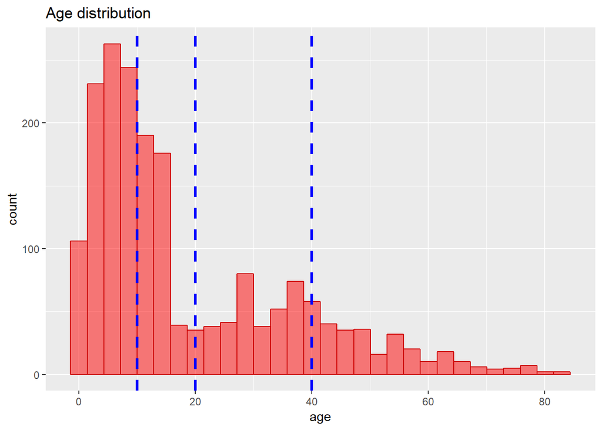

```r
library(ggplot2)
ggplot(scabies, aes(x=age)) +
  geom_histogram(color="red3", fill="red", position="dodge", alpha=0.5)+
  geom_vline(data=data.frame(mean=c(10,20,40)), aes(xintercept=mean),color="blue", size=1.2,
             linetype="dashed")+theme(legend.position="none")+
  labs(title="Age distribution")
```

The age distribution is split into 4 categories as depicted by the blue dashed vertical lines: 0-10, 11-20, 21-40 and older than 41 years.

```r
scabies$age_cat <- as.factor(cut(scabies$age, c(0,10,20,40,Inf), labels = c("0-10","11-20","21-40", "41+"), include.lowest = TRUE))
# check for correctness
table(scabies$age_cat)#, scabies$age)
```

```
##
##  0-10 11-20 21-40   41+
##   844   432   378   254
```

If looking at the tables below, we can see that the variables *age_cat* and *gender* are related to both scabies infestation *infest* and impetigo *impetigo_active* (each p<0.001).

```r
summary(tableby(infest~age_cat+gender, data=scabies, numeric.stats=c("median","meansd"), numeric.test="kwt"))
```

```
##
##
## |                         | 0 (N=1542)  |  1 (N=366)  | Total (N=1908) | p value|
## |:------------------------|:-----------:|:-----------:|:--------------:|-------:|
## |**age_cat**              |             |             |                | < 0.001|
## |&nbsp;&nbsp;&nbsp;0-10   | 651 (42.2%) | 193 (52.7%) |  844 (44.2%)   |        |
## |&nbsp;&nbsp;&nbsp;11-20  | 325 (21.1%) | 107 (29.2%) |  432 (22.6%)   |        |
## |&nbsp;&nbsp;&nbsp;21-40  | 336 (21.8%) | 42 (11.5%)  |  378 (19.8%)   |        |
## |&nbsp;&nbsp;&nbsp;41+    | 230 (14.9%) |  24 (6.6%)  |  254 (13.3%)   |        |
## |**gender**               |             |             |                | < 0.001|
## |&nbsp;&nbsp;&nbsp;female | 931 (60.4%) | 172 (47.0%) |  1103 (57.8%)  |        |
## |&nbsp;&nbsp;&nbsp;male   | 611 (39.6%) | 194 (53.0%) |  805 (42.2%)   |        |
```

```r
summary(tableby(impetigo_active~age_cat+gender, data=scabies, numeric.stats=c("median","meansd"), numeric.test="kwt"))
```

```
##
##
## |                         | no (N=1285) | yes (N=623) | Total (N=1908) | p value|
## |:------------------------|:-----------:|:-----------:|:--------------:|-------:|
## |**age_cat**              |             |             |                | < 0.001|
## |&nbsp;&nbsp;&nbsp;0-10   | 470 (36.6%) | 374 (60.0%) |  844 (44.2%)   |        |
## |&nbsp;&nbsp;&nbsp;11-20  | 275 (21.4%) | 157 (25.2%) |  432 (22.6%)   |        |
## |&nbsp;&nbsp;&nbsp;21-40  | 320 (24.9%) |  58 (9.3%)  |  378 (19.8%)   |        |
## |&nbsp;&nbsp;&nbsp;41+    | 220 (17.1%) |  34 (5.5%)  |  254 (13.3%)   |        |
## |**gender**               |             |             |                | < 0.001|
## |&nbsp;&nbsp;&nbsp;female | 832 (64.7%) | 271 (43.5%) |  1103 (57.8%)  |        |
## |&nbsp;&nbsp;&nbsp;male   | 453 (35.3%) | 352 (56.5%) |  805 (42.2%)   |        |
```

We have already determined overall RR and OR without acounting for *age* or *gender* using the *epi.2by2* function above. Now we want to get the specific odds ratios within *age_cat* and *gender* strata. Again, the *epi.2by2* function from the *epiR* package is used to make a 2x2 table. This time a third (stratification) factor (*gender* or *age_cat*) is added:

First, the contribution of factor *gender* is assessed.

```r
gend_str<-epi.2by2(table(relevel(scabies$infest,"1"), relevel(scabies$impetigo_active,"yes"), relevel(scabies$gender, "male")))
gend_str
```

```
##              Outcome +    Outcome -      Total        Inc risk *
## Exposed +          179          187        366              48.9
## Exposed -          444         1098       1542              28.8
## Total              623         1285       1908              32.7
##                  Odds
## Exposed +       0.957
## Exposed -       0.404
## Total           0.485
##
##
## Point estimates and 95 % CIs:
## -------------------------------------------------------------------
## Inc risk ratio (crude)                       1.70 (1.49, 1.94)
## Inc risk ratio (M-H)                         1.58 (1.39, 1.79)
## Inc risk ratio (crude:M-H)                   1.08
## Odds ratio (crude)                           2.37 (1.88, 2.99)
## Odds ratio (M-H)                             2.18 (1.72, 2.76)
## Odds ratio (crude:M-H)                       1.09
## Attrib risk (crude) *                        20.11 (14.52, 25.71)
## Attrib risk (M-H) *                          17.75 (5.52, 29.99)
## Attrib risk (crude:M-H)                      1.13
## -------------------------------------------------------------------
##  Test of homogeneity of IRR: X2 test statistic: 8.011 p-value: 0.005
##  Test of homogeneity of  OR: X2 test statistic: 0.629 p-value: 0.428
##  Wald confidence limits
##  M-H: Mantel-Haenszel
##  * Outcomes per 100 population units
```

The homogeneity test indicates that incidence risk ratio RR differs between males and females (p=0.005), but gender does not affect the odds of getting scabies given impetigo vs getting scabies without active impetigo, i.e. the odds ratio OR (p=0.428). This can be illustrated using a simple plot.

A function to add transparency to colours:

```r
# function to add transparency alpha to colours:
add.alpha <- function(col, alpha=1){
  if(missing(col))
    stop("Please provide a vector of colours.")
  apply(sapply(col, col2rgb)/255, 2,
        function(x)
          rgb(x[1], x[2], x[3], alpha=alpha))}
```

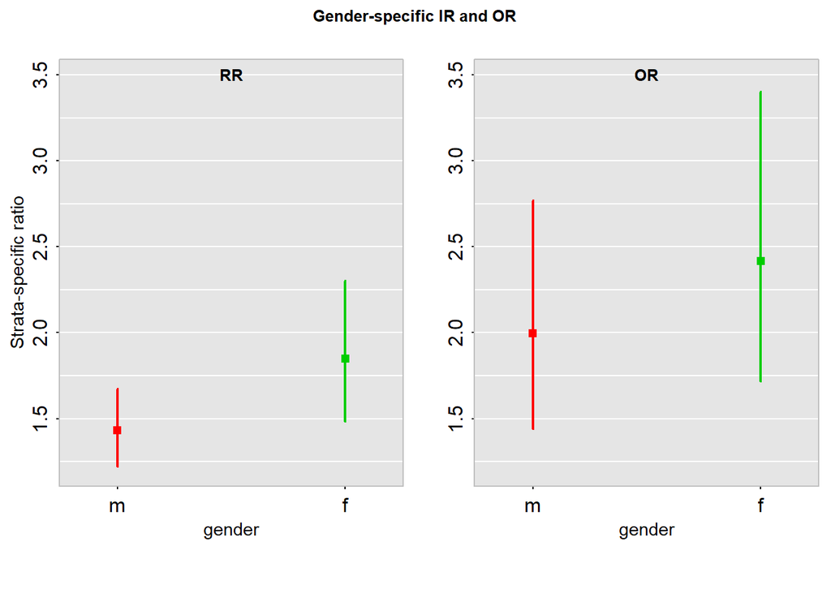

```r
# save the gender-specific incidence risk ratio RR and odds-ratio OR:
RR_str<-summary(gend_str)$RR.strata.wald
OR_str<-summary(gend_str)$OR.strata.wald
# plot gender-specific RR and OR
par(mfrow=c(1,2),mgp=c(1.5,0.4,0), tck=-0.008,omi=c(0,0,0,0), mai=c(0.9,0.5,0.5,0.1), cex=0.9, cex.axis=1.1, cex.main=0.9)
plot(x=c(0.8,2.2), y=c(0,0), ylim=c(1.2,3.5), xaxt="n", xlab="gender", ylab="Strata-specific ratio")
polygon(x=c(-10000,-10000,50000,50000),y=c(-500,50000,50000,-500),col=add.alpha(1,0.1),border=NA)
abline(h=seq(0, 10, 0.25), col='white')
lines(x=c(1,1,1), y=c(RR_str[1,]), col=2,lwd=2)
lines(x=c(2,2,2), y=c(RR_str[2,]), col=3,lwd=2)
points(x=c(1,2), y=RR_str[,1], col=c(2,3), pch=15)
axis(1, at=c(1,2), labels=c("m","f"))
title(main="RR", cex=0.8, line=-1, outer=F)
box(lty=1, col="grey75")

plot(x=c(0.8,2.2), y=c(0,0), ylim=c(1.2,3.5), xaxt="n", xlab="gender", ylab="")
polygon(x=c(-10000,-10000,50000,50000),y=c(-500,50000,50000,-500),col=add.alpha(1,0.1),border=NA)
abline(h=seq(0, 10, 0.25), col='white')
lines(x=c(1,1,1), y=c(OR_str[1,]), col=2,lwd=2)
lines(x=c(2,2,2), y=c(OR_str[2,]), col=3,lwd=2)
points(x=c(1,2), y=OR_str[,1], col=c(2,3), pch=15)
axis(1, at=c(1,2), labels=c("m","f"))
title(main="OR", cex=0.8, line=-1, outer=F)
box(lty=1, col="grey75")
title(main="Gender-specific IR and OR", outer=T, line=-1)
```

In conclusion, it is evident (p=0.005) that once impetigo is active, females have a higher relative risk (1.84, 95%CI: 1.48-2.30) of getting infected with scabies than males (1.43, 95%CI: 1.22-1.68). The odds of being infected with scabies when impetigo is active (exposed) vs not active (not exposed), on the other hand, are not affected by gender, i.e. they are homogeneous (p=0.428). If variable *gender* was a confounder, it would likely be indicated by a discrepancy between the crude OR (2.37, 95%CI: 1.88-2.99) and strata-specific ORs (male: 1.99, 95%CI: 1.44-2.77 ; female: 2.42, 95%CI: 1.72-3.40). Also, a deviance of crude OR from MH-based OR might indicate confounding. Often, a deviance of 10% is considered as an indicator of confounding. As in our sample the crude OR and MH-based OR deviate by ~9% (ratio of 1.09)). Thus we will have to keep *gender* in mind for modelling.

We can repeat the stratification procedure using factor *age_cat* now:

```r
age_str<-epi.2by2(table(relevel(scabies$infest,"1"), relevel(scabies$impetigo_active,"yes"), relevel(scabies$age_cat, "0-10")))
age_str
```

```
##              Outcome +    Outcome -      Total        Inc risk *
## Exposed +          179          187        366              48.9
## Exposed -          444         1098       1542              28.8
## Total              623         1285       1908              32.7
##                  Odds
## Exposed +       0.957
## Exposed -       0.404
## Total           0.485
##
##
## Point estimates and 95 % CIs:
## -------------------------------------------------------------------
## Inc risk ratio (crude)                       1.70 (1.49, 1.94)
## Inc risk ratio (M-H)                         1.47 (1.30, 1.67)
## Inc risk ratio (crude:M-H)                   1.15
## Odds ratio (crude)                           2.37 (1.88, 2.99)
## Odds ratio (M-H)                             1.96 (1.55, 2.49)
## Odds ratio (crude:M-H)                       1.21
## Attrib risk (crude) *                        20.11 (14.52, 25.71)
## Attrib risk (M-H) *                          15.58 (3.27, 27.89)
## Attrib risk (crude:M-H)                      1.29
## -------------------------------------------------------------------
##  Test of homogeneity of IRR: X2 test statistic: 15.9 p-value: 0.001
##  Test of homogeneity of  OR: X2 test statistic: 8.785 p-value: 0.032
##  Wald confidence limits
##  M-H: Mantel-Haenszel
##  * Outcomes per 100 population units
```

For factor *age_cat*, the homogeneity test indicates that both incidence risk ratios RR’s (p=0.001) and odds ratios OR’s (p=0.032) differ between the four age categories. Thus *age_cat* does affect the risk and odds of getting scabies given impetigo vs getting scabies without active impetigo. Again, this can be illustrated using a plot.

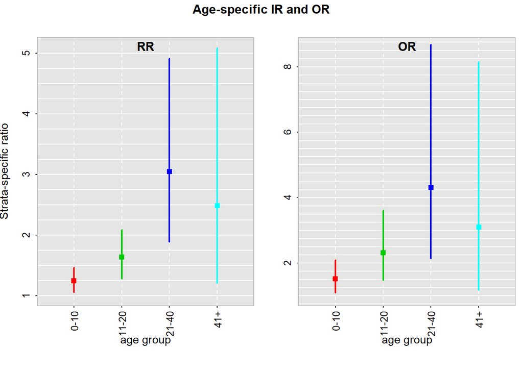

```r
# save the age-specific incidence risk ratio RR and odds-ratio OR:
RR_strage<-summary(age_str)$RR.strata.wald
OR_strage<-summary(age_str)$OR.strata.wald
# plot gender-specific RR and OR
par(mfrow=c(1,2),mgp=c(2,0.4,0), tck=-0.008,omi=c(0,0,0,0), mai=c(0.9,0.5,0.5,0.1), cex=0.9, cex.axis=0.9, cex.main=1.1)
plot(x=c(0.8,2.2), y=c(0,0), ylim=c(1,5.1), xaxt="n", xlab="age group", ylab="Strata-specific ratio")
polygon(x=c(-10000,-10000,50000,50000),y=c(-500,50000,50000,-500),col=add.alpha(1,0.1),border=NA)
abline(h=seq(0, 10, 0.25), col='white')
abline(v=seq(1, 2, length=4),lty=2, col='white')
for (i in 1:nrow(RR_strage)){lines(x=rep(seq(1,2,length=4)[i],3), y=c(RR_strage[i,]), col=i+1,lwd=2)}
points(x=seq(1,2,length=4), y=RR_strage[,1], col=c(2:5), pch=15)
axis(1, at=seq(1,2,length=4), labels=levels(scabies$age_cat), las=2)
title(main="RR", cex=0.8, line=-1, outer=F)
box(lty=1, col="grey75")

plot(x=c(0.8,2.2), y=c(0,0), ylim=c(1,8.6), xaxt="n", xlab="age group", ylab="")
polygon(x=c(-10000,-10000,50000,50000),y=c(-500,50000,50000,-500),col=add.alpha(1,0.1),border=NA)
abline(h=seq(0, 10, 0.25), col='white')
abline(v=seq(1, 2, length=4),lty=2, col='white')
for (i in 1:nrow(OR_strage)){lines(x=rep(seq(1,2,length=4)[i],3), y=c(OR_strage[i,]), col=i+1,lwd=2)}
points(x=seq(1,2,length=4), y=OR_strage[,1], col=c(2:5), pch=15)
axis(1, at=seq(1,2,length=4), labels=levels(scabies$age_cat), las=2)
title(main="OR", cex=0.8, line=-1, outer=F)
box(lty=1, col="grey75")
title(main="Age-specific IR and OR", outer=T, line=-1)
```

For factor *age_cat* it is evident (p=0.001) that the risk ratio of scabies infestation varies with age category. Younger people are least likely to get infested once impetigo is active (average RR of 1.25, 1.64, 3.05 and 2.48 for age groups 0-10, 11-20, 21-40 and 41+ respectively). The odds of being infected with scabies when impetigo is active (exposed) vs not active (not exposed) seem to be slightly more homogeneous (see Figure above), but do also vary with *age_cat* (p=0.032). There is a considerable deviance of crude OR from MH-based OR (~21% as theratio between crude OR and MH-based OR is 1.21) indicating that *age_cat* should be controlled for during modelling.

## Model Fitting

Now let’s fit a model of the association between active impetigo (exposure) and other potential covariates on scabies infestation (outcome). Given the binary response variable *infest* (yes or no), a logistic regression model is used.

Before we proceed, I would like to transform the potential numerical predictor *house_inhabitants* to a factor using categories 0-5, 6-10 and 11+ inhabitants: Now take a look at the number of people living together in a house and the split made (vertical dashed lines):

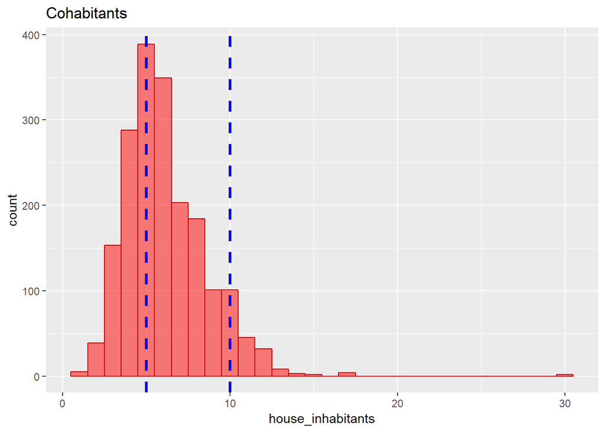

```r
ggplot(scabies, aes(x=house_inhabitants)) +
  geom_histogram(color="red3", fill="red", position="dodge", alpha=0.5)+
  geom_vline(data=data.frame(mean=c(5,10)), aes(xintercept=mean),color="blue", size=1.2,
             linetype="dashed")+theme(legend.position="none")+
  labs(title="Cohabitants")
```

```r
scabies$inhab_cat <- as.factor(cut(scabies$house_inhabitants, c(0,5,10,Inf), labels = c("0-5","6-10","11+"), include.lowest = TRUE))
# check for correctness
table(scabies$inhab_cat, scabies$house_inhabitants)
```

```
##
##          1   2   3   4   5   6   7   8   9  10  11  12  13  14  15  17  30
##   0-5    5  39 153 288 389   0   0   0   0   0   0   0   0   0   0   0   0
##   6-10   0   0   0   0   0 349 203 184 101 101   0   0   0   0   0   0   0
##   11+    0   0   0   0   0   0   0   0   0   0  45  32   8   3   2   4   2
```

For the model we set baseline *age_cat* as 0-10 years and *inhab_cat* as 0-5:

```r
scabies$age_cat <- relevel(scabies$age_cat, ref = "0-10")
scabies$inhab_cat <- relevel(scabies$inhab_cat, ref = "0-5")
```

The initial logit model with all potential covariates has the following form:

```r
glm1<-glm(infest ~ impetigo_active + age_cat + gender + inhab_cat + room_cohabitation, family=binomial(link="logit"), data=scabies)
summary(glm1)
```

```
##
## Call:
## glm(formula = infest ~ impetigo_active + age_cat + gender + inhab_cat +
##     room_cohabitation, family = binomial(link = "logit"), data = scabies)
##
## Deviance Residuals:
##     Min       1Q   Median       3Q      Max
## -1.0672  -0.6983  -0.5605  -0.3992   2.3843
##
## Coefficients:
##                    Estimate Std. Error z value Pr(>|z|)
## (Intercept)        -1.61337    0.20269  -7.960 1.72e-15 ***
## impetigo_activeyes  0.66575    0.12479   5.335 9.55e-08 ***
## age_cat11-20        0.16554    0.14193   1.166  0.24346
## age_cat21-40       -0.55957    0.19396  -2.885  0.00392 **
## age_cat41+         -0.77603    0.23709  -3.273  0.00106 **
## gendermale          0.27742    0.12477   2.224  0.02618 *
## inhab_cat6-10       0.31895    0.12632   2.525  0.01157 *
## inhab_cat11+        0.25694    0.28669   0.896  0.37014
## room_cohabitation  -0.07910    0.04466  -1.771  0.07650 .
## ---
## Signif. codes:  0 '***' 0.001 '**' 0.01 '*' 0.05 '.' 0.1 ' ' 1
##
## (Dispersion parameter for binomial family taken to be 1)
##
##     Null deviance: 1865.5  on 1907  degrees of freedom
## Residual deviance: 1769.2  on 1899  degrees of freedom
## AIC: 1787.2
##
## Number of Fisher Scoring iterations: 4
```

### Model selection

From the summary it seems likely that the variable *room_cohabitation* doesn’t contribute much to explain the association. The parsimony of competing nested models is assessed using likelihood-ratio-tests (LRTs) during model selection:

```r
glm2<-update(glm1, .~. -room_cohabitation)
library(lmtest)
lrtest(glm1,glm2)
```

```
## Likelihood ratio test
##
## Model 1: infest ~ impetigo_active + age_cat + gender + inhab_cat + room_cohabitation
## Model 2: infest ~ impetigo_active + age_cat + gender + inhab_cat
##   #Df  LogLik Df  Chisq Pr(>Chisq)
## 1   9 -884.60
## 2   8 -886.21 -1 3.2352    0.07207 .
## ---
## Signif. codes:  0 '***' 0.001 '**' 0.01 '*' 0.05 '.' 0.1 ' ' 1
```

Being conservative, we keep all variables with a p<0.05. Therefore *room-cohabitation* can be dropped (p~0.07).

```r
glm3<-update(glm2, .~. -inhab_cat)
lrtest(glm2,glm3)
```

```
## Likelihood ratio test
##
## Model 1: infest ~ impetigo_active + age_cat + gender + inhab_cat
## Model 2: infest ~ impetigo_active + age_cat + gender
##   #Df  LogLik Df  Chisq Pr(>Chisq)
## 1   8 -886.21
## 2   6 -888.69 -2 4.9608    0.08371 .
## ---
## Signif. codes:  0 '***' 0.001 '**' 0.01 '*' 0.05 '.' 0.1 ' ' 1
```

Same for house inhabitants (*inhab_cat*, p~0.084) But how about *gender*?

```r
lrtest(glm3,update(glm3, .~. -gender))
```

```
## Likelihood ratio test
##
## Model 1: infest ~ impetigo_active + age_cat + gender
## Model 2: infest ~ impetigo_active + age_cat
##   #Df  LogLik Df  Chisq Pr(>Chisq)
## 1   6 -888.69
## 2   5 -891.22 -1 5.0576    0.02452 *
## ---
## Signif. codes:  0 '***' 0.001 '**' 0.01 '*' 0.05 '.' 0.1 ' ' 1
```

As expected from previous analytical steps above, variable *gender* should stay in the model (p~0.025)

Assessing interaction terms:

```r
glm4<-glm(infest ~ impetigo_active + age_cat + gender + impetigo_active:age_cat, family=binomial(link="logit"), data=scabies)
lrtest(glm4,glm3)
```

```
## Likelihood ratio test
##
## Model 1: infest ~ impetigo_active + age_cat + gender + impetigo_active:age_cat
## Model 2: infest ~ impetigo_active + age_cat + gender
##   #Df  LogLik Df  Chisq Pr(>Chisq)
## 1   9 -884.67
## 2   6 -888.69 -3 8.0399    0.04519 *
## ---
## Signif. codes:  0 '***' 0.001 '**' 0.01 '*' 0.05 '.' 0.1 ' ' 1
```

Interaction between *age_cat* and *impetigo_active* should remain (p<0.05)

```r
glm5<-glm(infest ~ impetigo_active + age_cat + gender + impetigo_active:age_cat + impetigo_active:gender, family=binomial(link="logit"), data=scabies)
lrtest(glm5,glm4)
```

```
## Likelihood ratio test
##
## Model 1: infest ~ impetigo_active + age_cat + gender + impetigo_active:age_cat +
##     impetigo_active:gender
## Model 2: infest ~ impetigo_active + age_cat + gender + impetigo_active:age_cat
##   #Df  LogLik Df  Chisq Pr(>Chisq)
## 1  10 -884.67
## 2   9 -884.67 -1 0.0092     0.9238
```

Interaction between *impetigo_active* and *gender* should not stay in the model (p=0.92).

The final model selected is glm4.

### Predictions of scabies infestation

Let’s see what the predicted probability of scabies infestation is for different strata. First, a data frame with all combinations of predictors in glm4 is created (*pred*). Then, point estimates and SEs are predicted and added to the data frame *predic*.

```r
pred<-expand.grid(age_cat=levels(scabies$age_cat), gender=levels(scabies$gender), impetigo_active=levels(scabies$impetigo_active))
predic<-cbind(pred,data.frame(predict.glm(glm4, newdata=pred, type="response", se.fit=T)))
```

95% prediction intervals are obtained assuming a Normal distribution, with a t-multiplier of 1.96:

```r
predic<-cbind(predic[,-6], predic$fit-predic$se.fit*1.96, predic$fit, predic$fit+predic$se.fit*1.96)
colnames(predic)[6:8]<-c("pilow","pointest","pihigh")
colnames(predic)[3]<-"impet"
```

And the actual plot:

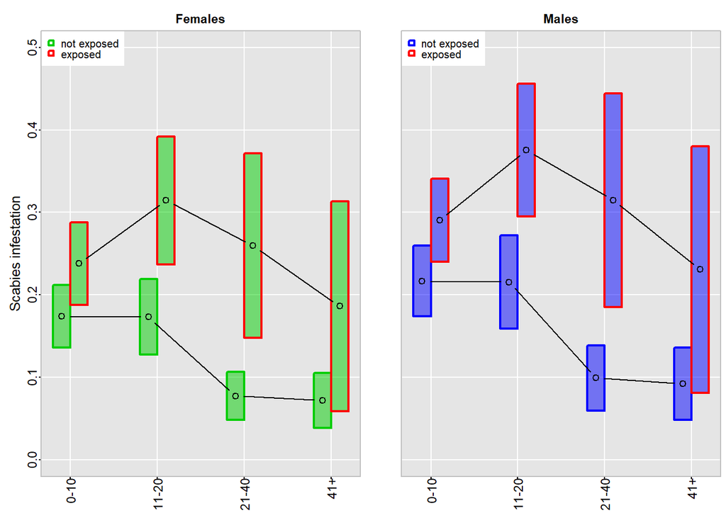

```r
par(mfrow=c(1,2),mgp=c(1.5,0.4,0), tck=-0.008,omi=c(0,0,0,0), mai=c(0.6,0.5,0.5,0.1), cex=0.9, cex.axis=0.9, cex.main=1.1)
par(mfrow=c(1,2),mgp=c(1.1,0.1,0), tck=-0.008,omi=c(0,0,0.0,0.05), mai=c(0.4,0.4,0.3,0),cex=0.8, cex.axis=0.9,cex.main=1.1)

plot(0,0, ylim=c(0,0.5),xlim=c(0.8,4.2),xlab="", xaxt="n",ylab="Scabies infestation", col=NA)
polygon(x=c(-10000,-10000,50000,50000),y=c(-500,50000,50000,-500),col=add.alpha(1,0.1),border=NA)
abline(v=seq(0,100,1), col='white')
abline(h=seq(0, 5, 0.1), col='white')

# plot the effect of exposure (active impetigo) on scabies infetstation in females first:
dat<-predic[predic$impet=="no" & predic$gender=="female",]
for (i in 1:length(levels(scabies$age_cat))){
polygon(c(i+c(-0.2,0,0,-0.2)), c(dat[i,c(8,8,6,6)]), col=add.alpha(3,0.5), border=3, lwd=2)}
points(c(1:4)-0.1, dat[,"fit"], type="b")
dat<-predic[predic$impet=="yes" & predic$gender=="female",]
for (i in 1:length(levels(scabies$age_cat))){
polygon(c(i+c(0,0.2,0.2,0)), c(dat[i,c(8,8,6,6)]), col=add.alpha(3,0.5), border=2, lwd=2)}
points(c(1:4)+0.1, dat[,"fit"], type="b")
axis(1, at=c(1:4), labels=c(levels(scabies$age_cat)), las=2)
legend("topleft",legend=c("not exposed", "exposed"), y.intersp=0.8, pch=0,pt.lwd=2,col=c(3,2), box.col="white", cex=0.8)
title(main="Females", cex.main=0.9, line=0.5, outer=F)
box(lty=1, col="grey75")
# plot for males now:
plot(0,0, ylim=c(0,0.5),xlim=c(0.8,4.2),xlab="", yaxt="n",xaxt="n",ylab="", col=NA)
polygon(x=c(-10000,-10000,50000,50000),y=c(-500,50000,50000,-500),col=add.alpha(1,0.1),border=NA)
abline(v=seq(0,100,1), col='white')
abline(h=seq(0, 5, 0.1), col='white')
dat<-predic[predic$impet=="no" & predic$gender=="male",]
for (i in 1:length(levels(scabies$age_cat))){
polygon(c(i+c(-0.2,0,0,-0.2)), c(dat[i,c(8,8,6,6)]), col=add.alpha(4,0.5), border=4, lwd=2)}
points(c(1:4)-0.1, dat[,"fit"], type="b")

dat<-predic[predic$impet=="yes" & predic$gender=="male",]
for (i in 1:length(levels(scabies$age_cat))){
polygon(c(i+c(0,0.2,0.2,0)), c(dat[i,c(8,8,6,6)]), col=add.alpha(4,0.5), border=2, lwd=2)}
points(c(1:4)+0.1, dat[,"fit"], type="b")
axis(1, at=c(1:4), labels=c(levels(scabies$age_cat)), las=2)
title(main="Males", cex.main=0.9, line=0.5, outer=F)
legend("topleft",legend=c("not exposed", "exposed"), y.intersp=0.8, pch=0,pt.lwd=2,col=c(4,2), box.col="white", cex=0.8)
box(lty=1, col="grey75")
```